# TiDEomics Application: Macrophage response to six immune stimuli

# 11 Variance decomposition analysis

## 11.1 Filter input

Input features are filtered to have at least 50% values > 0 in at least 2 groups, as comparison between groups is needed.

```r
filter_ratio <- 0.5
decomp_filter_genes <- group_specific_features(property_random_fc,
    filter_ratio = filter_ratio,
    group_pct = 2 / length(unique(data_obj$Group)),
    GO = FALSE, genename = FALSE
)
```

```
#> Filtering criteria: >=50% values >0 in >=2 of groups: Candida, IFNbeta, IFNgamma, LCMV, Listeria, LPS, untreated
```

## 11.2 Original data (not time 0 normalised) with replicates

Compared to normalised data, only using original data can identify genes with stable but different levels of expression in groups.

```r
var_decomp_1 <- decomp_variance(data_obj,
    features = decomp_filter_genes,
    assay = 1, core = 16
)
```

```
#> LMM: exp ~ (1|Group) + (1|Time)  |  Output: Group, Time, Residual
```

```
#> Features not specified. Plotting top 20 features ranked by Time.
```

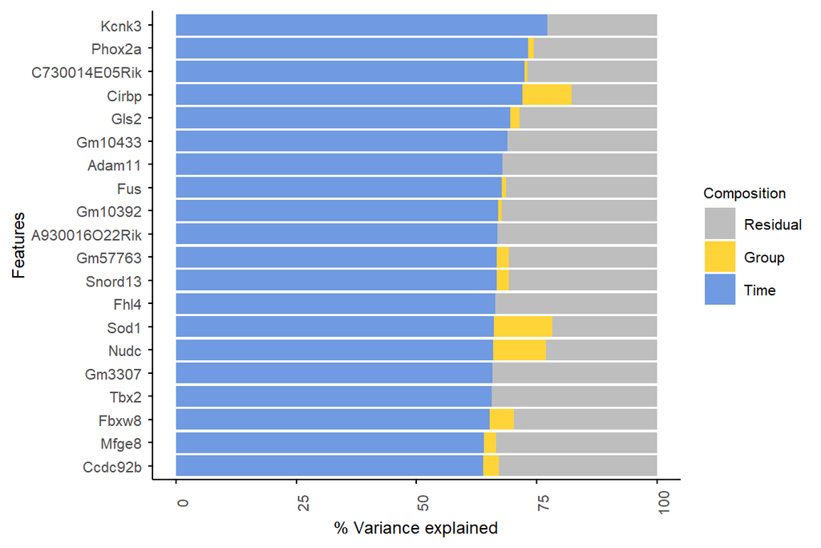

```r
plot_variance(var_decomp_1, rank = "Time", top_n = 20)
```

```
#> Features not specified. Plotting top 20 features ranked by Group.
```

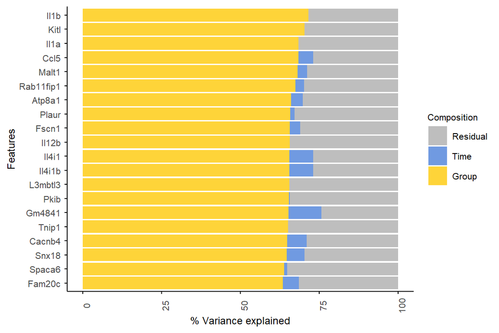

```r
plot_variance(var_decomp_1, rank = "Group", top_n = 20)
```

```
#> Group not specified. Plotting all groups: Candida, IFNbeta, IFNgamma, LCMV, Listeria, LPS, untreated
#> Warning: Removed 90 rows containing missing values or values outside the scale range
#> (`geom_point()`).
```

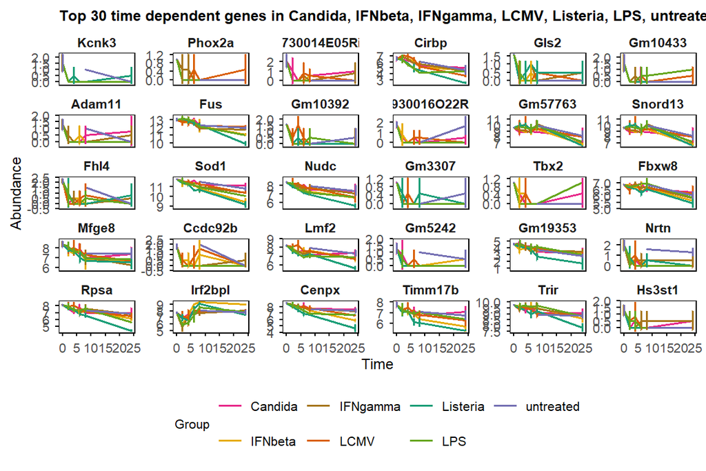

```r
plot_trend(table_mean_sd_orig,
    features = var_decomp_1 %>% arrange(desc(Time)) %>% head(30) %>% pull(Feature),
    title = "Top 30 time dependent genes"
)
```

```
#> Group not specified. Plotting all groups: Candida, IFNbeta, IFNgamma, LCMV, Listeria, LPS, untreated
#> Warning: Removed 90 rows containing missing values or values outside the scale range
#> (`geom_point()`).
```

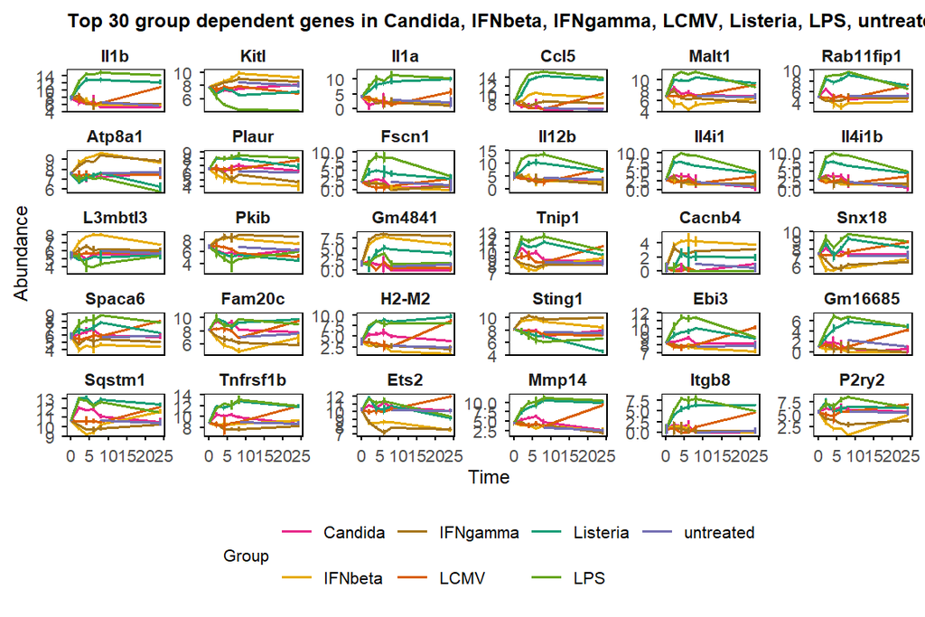

```r
plot_trend(table_mean_sd_orig,
    features = var_decomp_1 %>% arrange(desc(Group)) %>% head(30) %>% pull(Feature),
    title = "Top 30 group dependent genes"
)
```

### 11.2.1 Residual variance quantified data quality

```
#> Group not specified. Plotting all groups: Candida, IFNbeta, IFNgamma, LCMV, Listeria, LPS, untreated
#> Warning: Removed 90 rows containing missing values or values outside the scale range
#> (`geom_point()`).
```

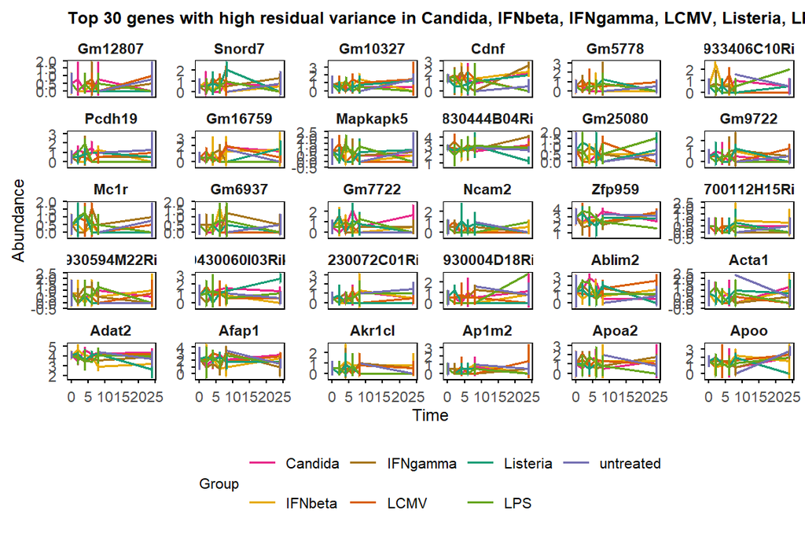

```r
plot_trend(table_mean_sd_orig,
    features = var_decomp_1 %>% arrange(desc(Residual)) %>% head(30) %>% pull(Feature),
    title = "Top 30 genes with high residual variance"
)
```

```
#> Group not specified. Plotting all groups: Candida, IFNbeta, IFNgamma, LCMV, Listeria, LPS, untreated
#> Warning: Removed 90 rows containing missing values or values outside the scale range
#> (`geom_point()`).
```

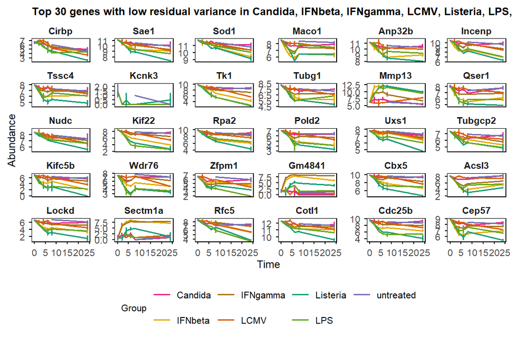

```r
plot_trend(table_mean_sd_orig,
    features = var_decomp_1 %>% arrange(Residual) %>% head(30) %>% pull(Feature),
    title = "Top 30 genes with low residual variance"
)
```

### 11.2.2 GO enrichment of genes ranked by group/time-contributed variance

`enrichGO_rank()` returns a named list indexed by GO category (e.g. `$BP`, `$MF`, `$CC`). Access results with `$BP` before passing to `enrichplot::gseaplot2()`.

```r
gse_group <- enrichGO_rank(var_decomp_1,
    gene_rank_by = "Group",
    OrgDb = org.Mm.eg.db,
    keyType = "SYMBOL", category = "BP",
    go_rank_by = "p.adjust")
```

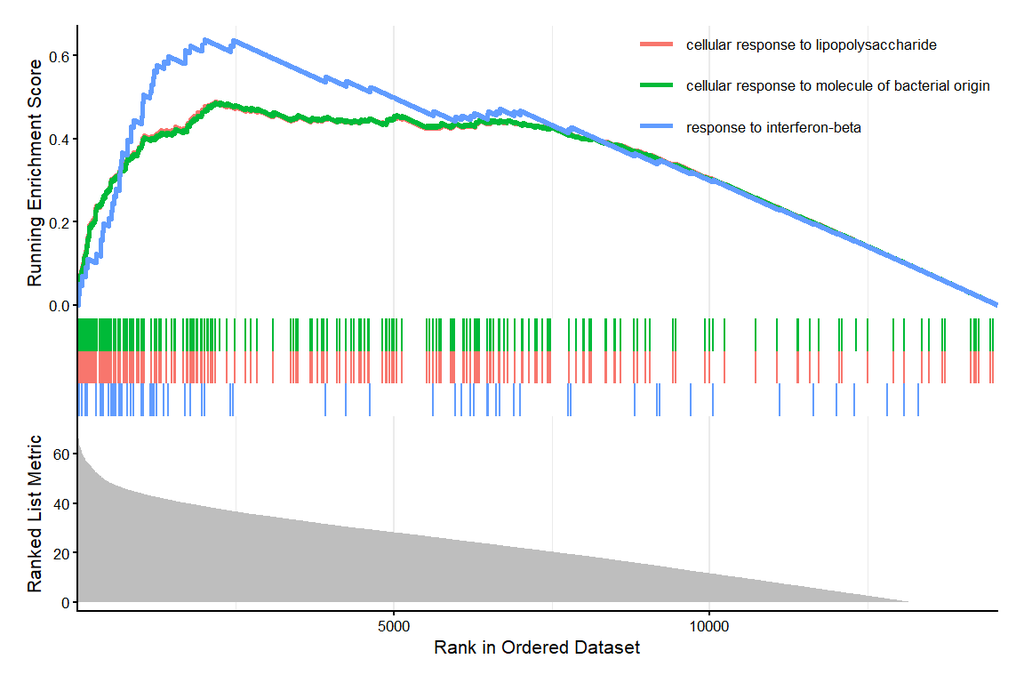

```r
enrichplot::gseaplot2(gse_group[["BP"]], geneSetID = 1:3, base_size = 8)
```

```r
gse_time <- enrichGO_rank(var_decomp_1,
    gene_rank_by = "Time",
    OrgDb = org.Mm.eg.db,
    keyType = "SYMBOL", category = "BP",
    go_rank_by = "p.adjust")
```

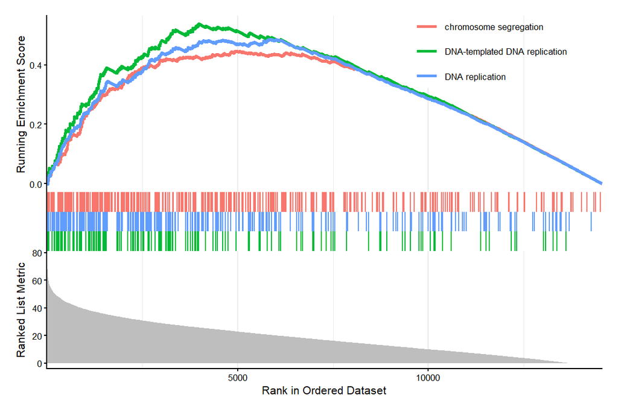

```r
enrichplot::gseaplot2(gse_time[["BP"]], geneSetID = 1:3, base_size = 8)
```

## 11.3 Time 0 normalised data with replicates

Time 0 normalised data will be used as WGCNA input, so variance decomposition is also performed on time 0 normalised data to filter for WGCNA input

```r
var_decomp_2 <- decomp_variance(data_obj,
    features = decomp_filter_genes,
    assay = 2, core = 16
)
```

```
#> LMM: exp ~ (1|Group) + (1|Time)  |  Output: Group, Time, Residual
```

```
#> Features not specified. Plotting top 20 features ranked by Time.
```

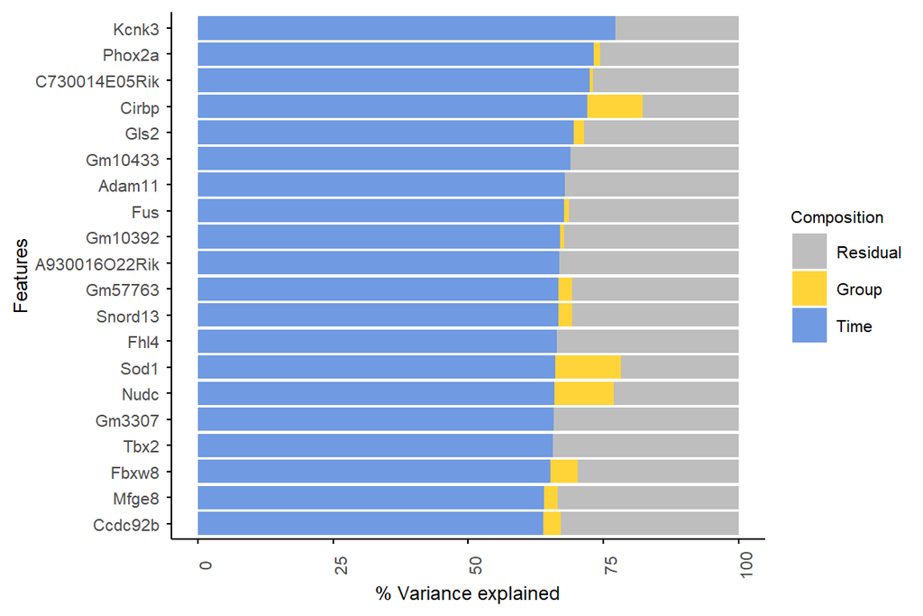

```r
plot_variance(var_decomp_2, rank = "Time", top_n = 20)
```

```
#> Features not specified. Plotting top 20 features ranked by Group.
```

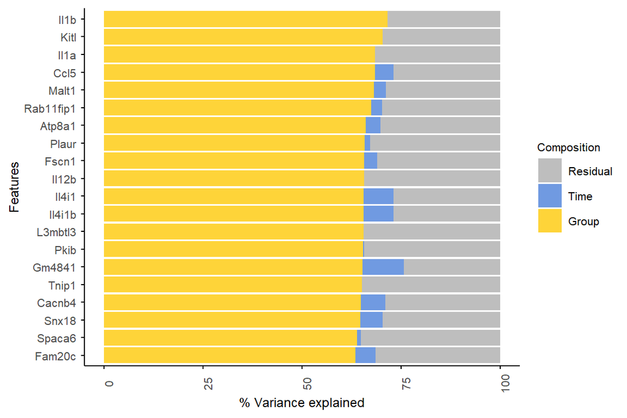

```r
plot_variance(var_decomp_2, rank = "Group", top_n = 20)
```

## 11.4 Compare variance with / without time 0 normalisation

var_decomp_1: not normalised to time 0

var_decomp_2: normalised to time 0

In this dataset, all groups have the same starting status (untreated), so after normalisation to time 0, the variance decomposition is the same as the original data.

```r
var_decomp_1$Residual %>% summary()
```

```
#>    Min. 1st Qu.  Median    Mean 3rd Qu.    Max.
#>   17.71   44.19   57.96   60.51   76.15  100.00
var_res_q3_1 <- quantile(var_decomp_1$Residual, 0.75)

var_decomp_2$Residual %>% summary()
```

```
#>    Min. 1st Qu.  Median    Mean 3rd Qu.    Max.
#>   17.71   44.19   57.96   60.51   76.15  100.00
var_res_q3_2 <- quantile(var_decomp_2$Residual, 0.75)
```

```r
var_decomp_merged <- merge(var_decomp_1, var_decomp_2,
    by = "Feature",
    suffixes = c(".orig", ".norm")
)

summary(var_decomp_merged$Residual.orig / var_decomp_merged$Residual.norm)
```

```
#>    Min. 1st Qu.  Median    Mean 3rd Qu.    Max.
#>       1       1       1       1       1       1
```

# 12 Module identification with WGCNA

WGCNA reference: https://github.com/edo98811/WGCNA_official_documentation/

## 12.1 Filter input

exclude genes with high residual variance

```r
# time 0 normalised
gene_resid_2 <- var_decomp_2 %>%
    filter(Residual < var_res_q3_2) %>%
    pull(Feature)
length(gene_resid_2) # only including genes with >=50% values >0 in >=2 groups
```

```
#> [1] 10909
```

exclude genes that are random in all groups

```r
non_random_union <- Reduce(union, non_random_list)
length(non_random_union) # all non-random genes have >=50% non NA
```

```
#> [1] 7628
```

include genes with at least 50% values > 0 in only one group, which were excluded from variance decomposition analysis

```r
group_unique_genes = Reduce(union, group_unique_genes_list)
stopifnot(group_unique_genes %>% unique() %>% length() == length(group_unique_genes))

length(group_unique_genes)
```

```
#> [1] 769
```

use time 0 normalised data with replicates

```r
filter_wgcna <- intersect(gene_resid_2, non_random_union) %>%
    union(group_unique_genes)
length(filter_wgcna)
```

```
#> [1] 7292

data_obj_filtered <- data_obj[filter_wgcna, ]
dim(data_obj_filtered)
```

```
#> [1] 7292   76
```

## 12.2 Choose power

```r
wgcna_input <- prepare_WGCNA(data_obj_filtered,
    assay = 2,
    blockSize = 20000,
    powers = c(seq(1, 30, by = 1)),
    networkType = "signed",
    RsquaredCut = 0.8,
    MeanConnectivity = 100
)
```

```
#> Allowing multi-threading with up to 24 threads.
#>  pickSoftThreshold: calculating connectivity for given powers...
#>    ..working on genes 1 through 7292 of 7292
#>    Power SFT.R.sq  slope truncated.R.sq mean.k. median.k. max.k.
#> 1      1   0.8560  3.500         0.8220  4390.0   4690.00   5240
#> 2      2   0.5040  1.020         0.4130  2910.0   3210.00   4100
#> 3      3   0.0547  0.214        -0.1110  2060.0   2290.00   3360
#> 4      4   0.0303 -0.131        -0.1970  1530.0   1680.00   2830
#> 5      5   0.1870 -0.312        -0.0443  1170.0   1250.00   2420
#> 6      6   0.3340 -0.425         0.1540   918.0    950.00   2100
#> 7      7   0.4470 -0.536         0.3360   735.0    730.00   1850
#> 8      8   0.5130 -0.618         0.4470   598.0    567.00   1630
#> 9      9   0.5610 -0.707         0.5550   493.0    444.00   1450
#> 10    10   0.5880 -0.783         0.6250   410.0    351.00   1300
#> 11    11   0.6240 -0.835         0.6900   345.0    279.00   1170
```

[output cut: 19 more lines]

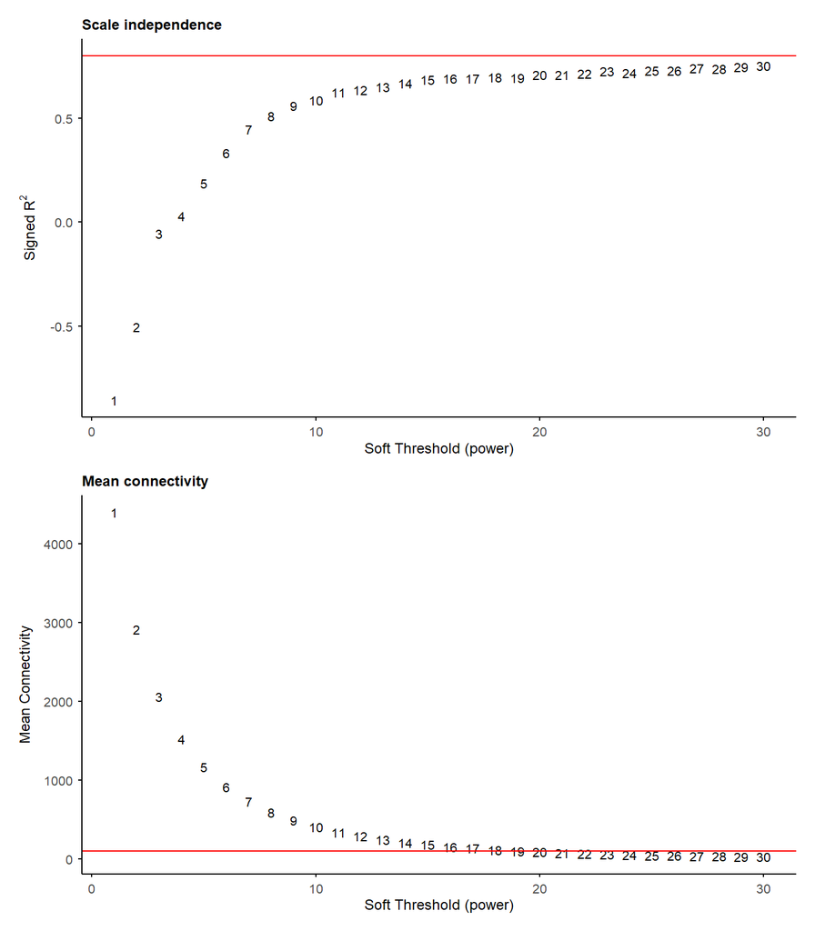

The R2 didn’t reach 0.8 under power 30, so choose the lowest power that reached the plateau.

## 12.3 Run WGCNA

```r
picked_power <- 12
minCoreKME <- 0.9
minKMEtoStay <- 0.7
reassignThreshold <- 0

net <- run_WGCNA(wgcna_input,
    power = picked_power,
    maxBlockSize = 20000,
    numericLabels = TRUE,
    minCoreKME = minCoreKME,
    minKMEtoStay = minKMEtoStay,
    reassignThreshold = reassignThreshold,
    verbose = 3
)
```

```
#> Allowing multi-threading with up to 24 threads.
#>  Calculating module eigengenes block-wise from all genes
#>    Flagging genes and samples with too many missing values...
#>     ..step 1
#>  ..Working on block 1 .
#>     TOM calculation: adjacency..
#>     ..will not use multithreading.
#>      Fraction of slow calculations: 0.000000
#>     ..connectivity..
#>     ..matrix multiplication (system BLAS)..
#>     ..normalization..
#>     ..done.
#>  ....clustering..
#>  ....detecting modules..
#>  ....calculating module eigengenes..
#>  ....checking kME in modules..
#>      ..removing 979 genes from module 1 because their KME is too low.
#>      ..removing 295 genes from module 2 because their KME is too low.
#>      ..removing 373 genes from module 3 because their KME is too low.
#>      ..removing 121 genes from module 4 because their KME is too low.
#>      ..removing 72 genes from module 5 because their KME is too low.
#>      ..removing 178 genes from module 6 because their KME is too low.
#>      ..removing 102 genes from module 7 because their KME is too low.
#>      ..removing 132 genes from module 8 because their KME is too low.
#>      ..removing 68 genes from module 9 because their KME is too low.
#>      ..removing 48 genes from module 10 because their KME is too low.
#>      ..removing 30 genes from module 12 because their KME is too low.
#>      ..removing 14 genes from module 13 because their KME is too low.
#>      ..removing 27 genes from module 14 because their KME is too low.
#>      ..removing 13 genes from module 16 because their KME is too low.
#>      ..removing 1 genes from module 18 because their KME is too low.
#>  ..merging modules that are too close..
#>      mergeCloseModules: Merging modules whose distance is less than 0.15
#>        Calculating new MEs...
# save(net, file = paste0("output\\GSE263759_WGCNA_net_p", picked_power, "_", Sys.Date(), ".rda"))
```

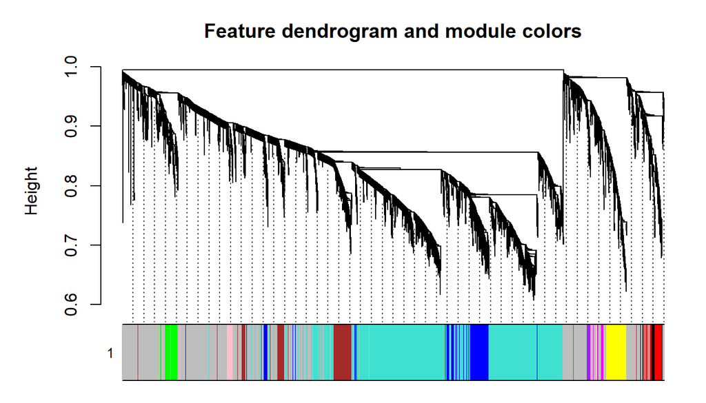

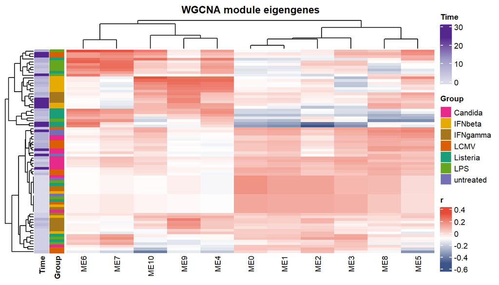

[output not shown]

[output cut: 10 more lines]

[output not shown]

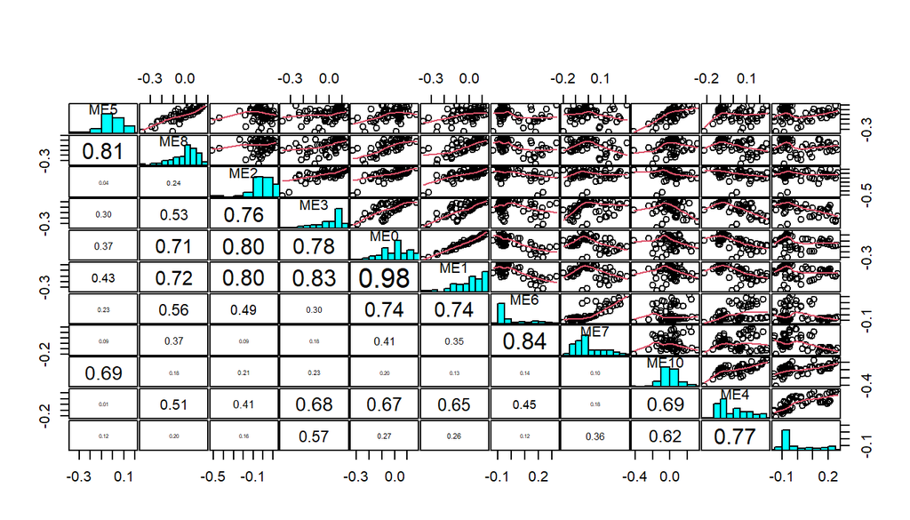

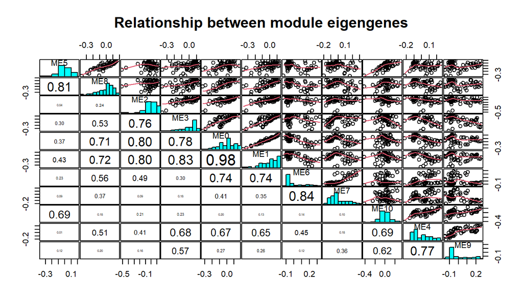

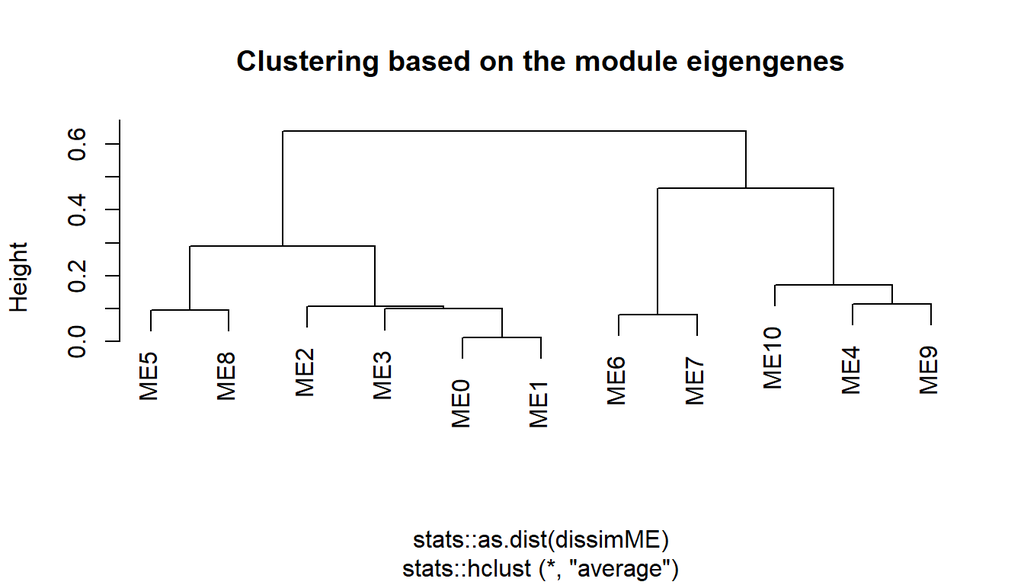

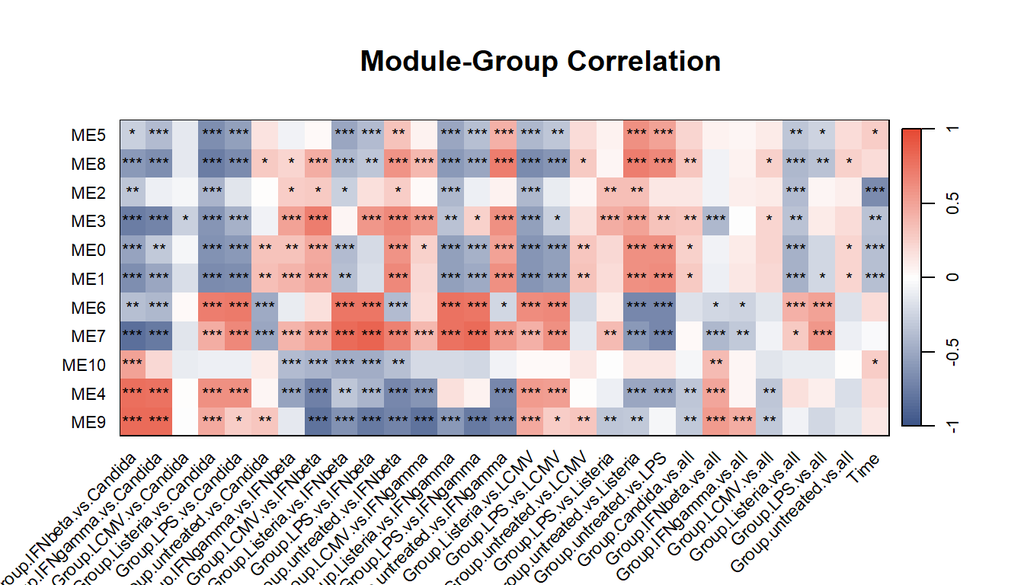

```r
plot_WGCNA(net = net)
```

`WGCNA_module()` converts the WGCNA network output to a standardised two-column data.frame (`Feature`, `Module`), accepted by all downstream plotting and enrichment functions. It optionally excludes the grey (unassigned) module.

```r
gene_module <- WGCNA_module(net)

gene_module %>%
    dplyr::group_by(Module) %>%
    dplyr::summarise(n = n())
```

| Module | n |
| --- | --- |
| 0 | 2708 |
| 1 | 2856 |
| 2 | 442 |
| 3 | 416 |
| 4 | 274 |
| 5 | 194 |
| 6 | 141 |
| 7 | 80 |
| 8 | 75 |
| 9 | 59 |

[output cut: 1 more lines]

```r
n_module <- length(unique(gene_module$Module)) - 1  # excluding grey (0)
```

## 12.4 Visualise example genes in each module

```
#> Group not specified. Plotting all groups: Candida, IFNbeta, IFNgamma, LCMV, Listeria, LPS, untreated
#> Warning: Removed 90 rows containing missing values or values outside the scale range
#> (`geom_point()`).
```

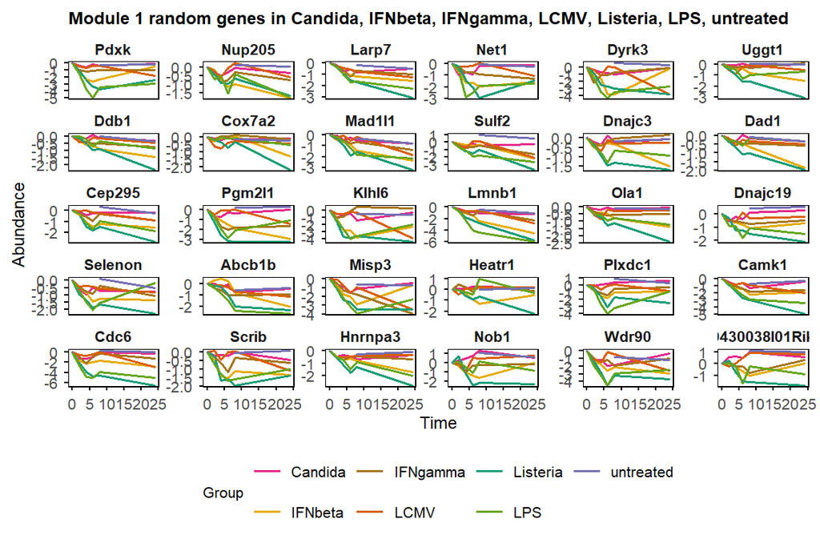

```
#> Group not specified. Plotting all groups: Candida, IFNbeta, IFNgamma, LCMV, Listeria, LPS, untreated
#> Warning: Removed 90 rows containing missing values or values outside the scale range
#> (`geom_point()`).
```

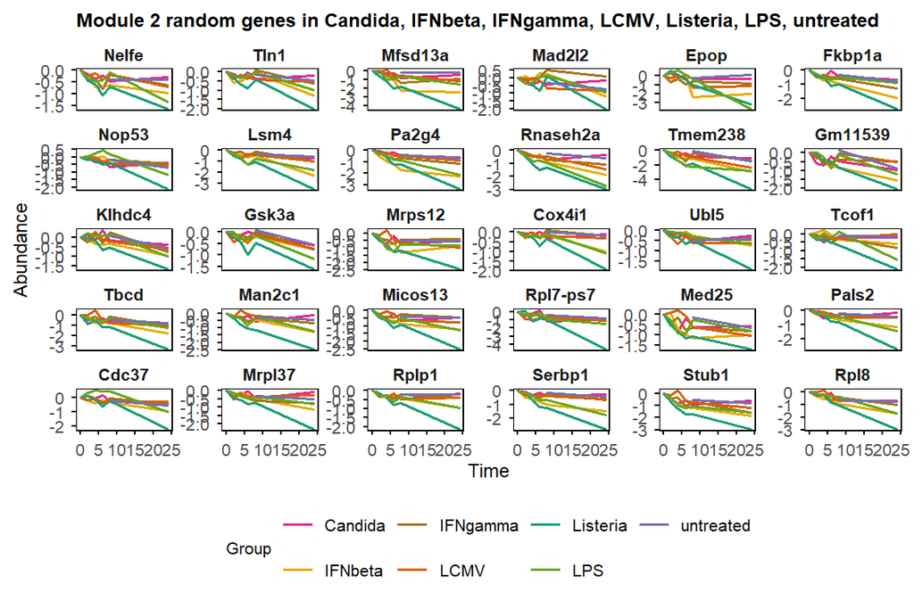

```
#> Group not specified. Plotting all groups: Candida, IFNbeta, IFNgamma, LCMV, Listeria, LPS, untreated
#> Warning: Removed 90 rows containing missing values or values outside the scale range
#> (`geom_point()`).
```

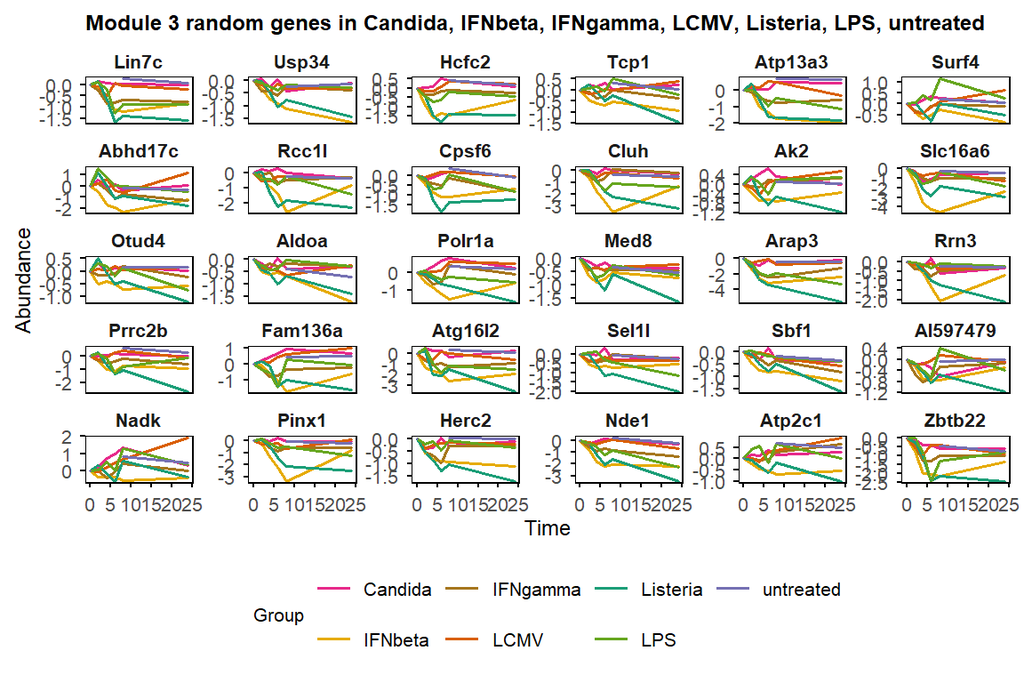

```
#> Group not specified. Plotting all groups: Candida, IFNbeta, IFNgamma, LCMV, Listeria, LPS, untreated
#> Warning: Removed 90 rows containing missing values or values outside the scale range
#> (`geom_point()`).
```

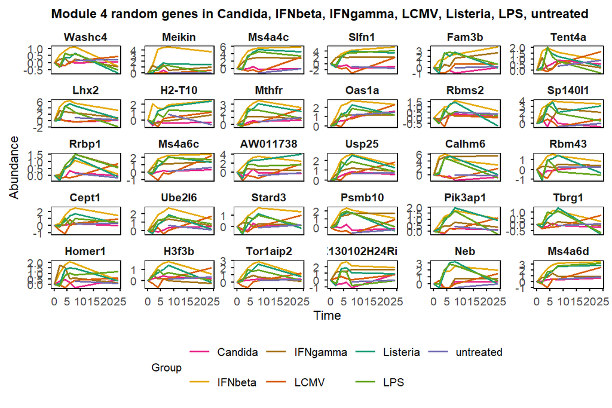

```
#> Group not specified. Plotting all groups: Candida, IFNbeta, IFNgamma, LCMV, Listeria, LPS, untreated
#> Warning: Removed 90 rows containing missing values or values outside the scale range
#> (`geom_point()`).
```

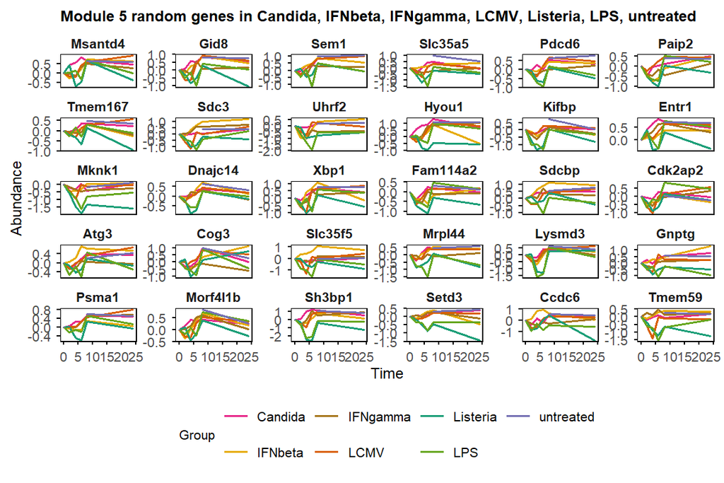

```
#> Group not specified. Plotting all groups: Candida, IFNbeta, IFNgamma, LCMV, Listeria, LPS, untreated
#> Warning: Removed 90 rows containing missing values or values outside the scale range
#> (`geom_point()`).
```

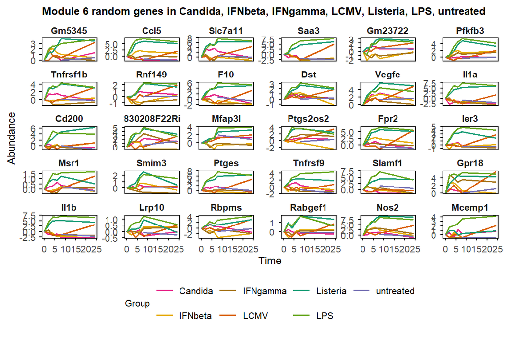

```
#> Group not specified. Plotting all groups: Candida, IFNbeta, IFNgamma, LCMV, Listeria, LPS, untreated
#> Warning: Removed 90 rows containing missing values or values outside the scale range
#> (`geom_point()`).
```

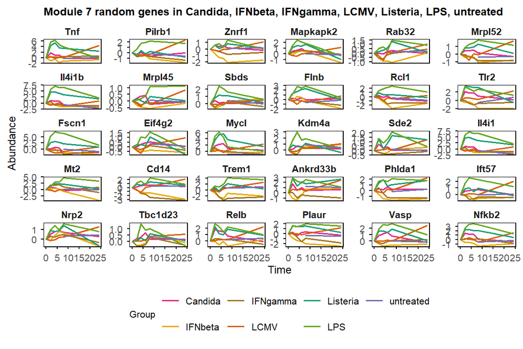

```
#> Group not specified. Plotting all groups: Candida, IFNbeta, IFNgamma, LCMV, Listeria, LPS, untreated
#> Warning: Removed 90 rows containing missing values or values outside the scale range
#> (`geom_point()`).
```

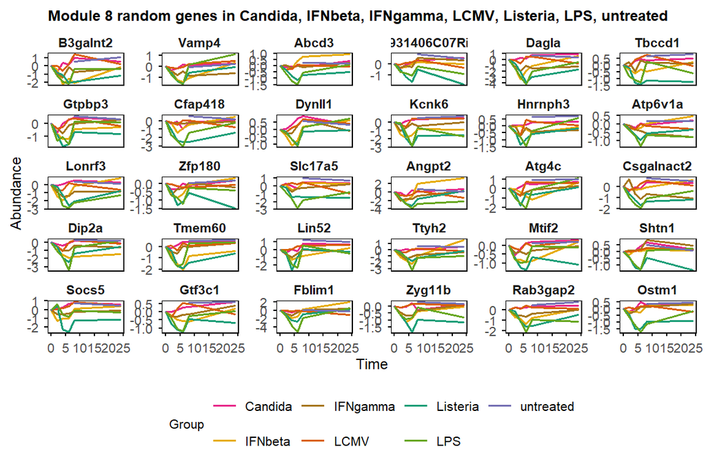

```
#> Group not specified. Plotting all groups: Candida, IFNbeta, IFNgamma, LCMV, Listeria, LPS, untreated
#> Warning: Removed 90 rows containing missing values or values outside the scale range
#> (`geom_point()`).
```

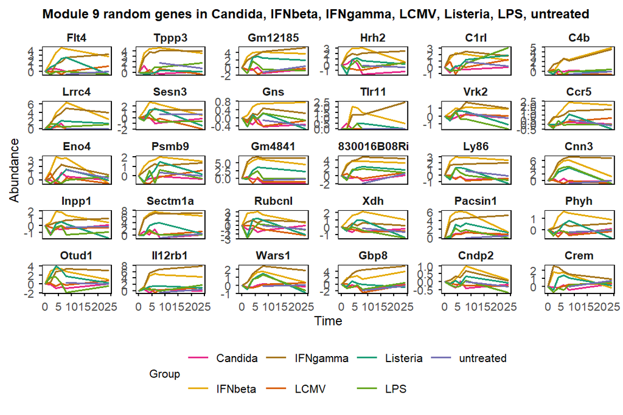

```
#> Group not specified. Plotting all groups: Candida, IFNbeta, IFNgamma, LCMV, Listeria, LPS, untreated
#> Warning: Removed 90 rows containing missing values or values outside the scale range
#> (`geom_point()`).
```

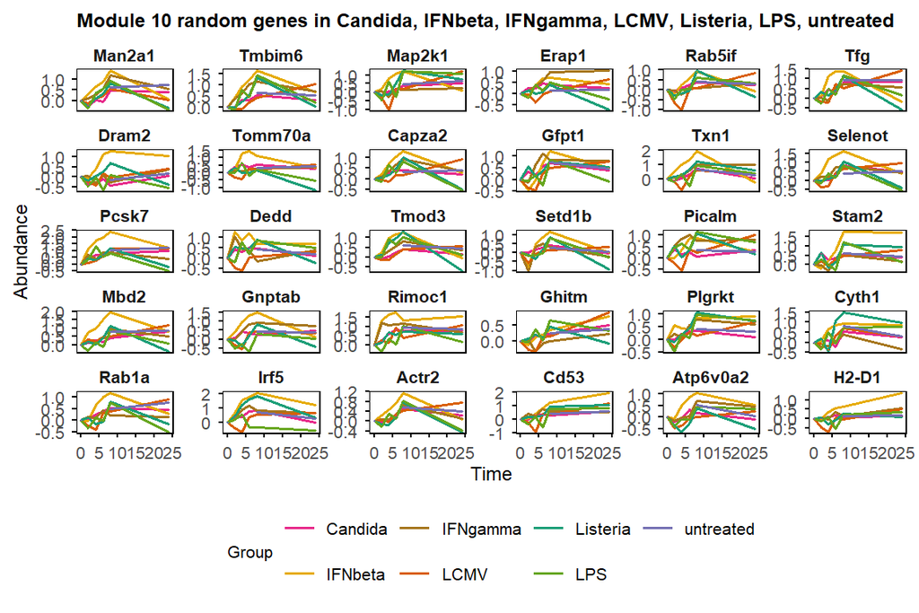

```r
for (i in seq(1, n_module)) {
    module_genes <- gene_module %>%
        filter(Module == i) %>%
        dplyr::select(Feature) %>%
        pull()

    random <- sample(module_genes, min(30, length(module_genes)))

    plot_trend(table_mean_sd_norm,
        errorbar = FALSE,
        features = random,
        title = paste0("Module ", i, " random genes")
    )
}
```

## 12.5 Summarise module segment pattern

integrate with output from Trendy.

```r
trendy_genes_pattern_list <- summarise_module_pattern(
    module = gene_module,
    trendy_summary = trendy_summary
)
```

```
#> Most common pattern in each module (Candida, IFNbeta, IFNgamma, LCMV, Listeria, LPS):
#> Module 1: NA, NA, NA, NA, stable_stable, NA
#> Module 2: NA, down, down, NA, down, down
#> Module 3: NA, down_stable, NA, NA, stable_stable, NA
#> Module 4: NA, up_down, NA, stable_up, NA, NA
#> Module 5: NA, NA, NA, up, NA, NA
#> Module 6: NA, NA, NA, NA, up, NA
#> Module 7: down, down_stable, NA, NA, up_down, up_down
#> Module 8: NA, NA, NA, NA, stable_stable, NA
#> Module 9: NA, up_down, NA, NA, NA, NA
#> Module 10: NA, up_stable, NA, NA, NA, NA
#> Module 1 top 5 patterns:
```

```
#>       Candida, IFNbeta, IFNgamma, LCMV, Listeria, LPS Count
#> 1                   NA, NA, NA, NA, stable_stable, NA    28
#> 2                NA, down_up, NA, NA, down_stable, NA    22
#> 3          NA, down_stable, NA, NA, stable_stable, NA    20
#> 4   NA, down_up, NA, down, down_stable, stable_stable    18
#> 5 NA, down_stable, NA, down, down_stable, down_stable    14
#> Module 2 top 5 patterns:
```

```
#>   Candida, IFNbeta, IFNgamma, LCMV, Listeria, LPS Count
#> 1                  NA, down, down, NA, down, down    13
#> 2                    NA, down, NA, NA, down, down     8
#> 3                NA, down, down, down, down, down     7
#> 4                  NA, down, NA, down, down, down     5
#> 5       NA, down, stable_stable, down, down, down     4
#> Module 3 top 5 patterns:
```

```
#>   Candida, IFNbeta, IFNgamma, LCMV, Listeria, LPS Count
#> 1      NA, down_stable, NA, NA, stable_stable, NA    11
#> 2            NA, down_up, NA, NA, down_stable, NA    11
#> 3          NA, down_up, NA, NA, stable_stable, NA    11
#> 4               NA, NA, NA, NA, stable_stable, NA     7
#> 5                      NA, down, NA, NA, down, NA     5
#> Module 4 top 5 patterns:
```

```
#>   Candida, IFNbeta, IFNgamma, LCMV, Listeria, LPS Count
#> 1              NA, up_down, NA, stable_up, NA, NA     5
#> 2                   NA, up_stable, NA, NA, NA, NA     5
#> 3                   NA, up_stable, NA, up, NA, NA     4
#> 4            NA, up_stable, up_stable, NA, NA, NA     4
#> 5                     NA, up_down, NA, NA, NA, NA     3
#> Module 5 top 5 patterns:
```

```
#>   Candida, IFNbeta, IFNgamma, LCMV, Listeria, LPS Count
#> 1                          NA, NA, NA, up, NA, NA    23
#> 2                          NA, up, NA, NA, NA, NA     7
#> 3                   up_stable, NA, NA, up, NA, NA     7
#> 4                          up, NA, NA, NA, NA, NA     6
#> 5               NA, NA, NA, NA, stable_stable, NA     5
#> Module 6 top 5 patterns:
```

```
#>   Candida, IFNbeta, IFNgamma, LCMV, Listeria, LPS Count
#> 1                          NA, NA, NA, NA, up, NA     5
#> 2              NA, NA, NA, NA, up_stable, up_down     4
#> 3     NA, NA, NA, stable_up, up_stable, up_stable     3
#> 4               NA, NA, NA, NA, NA, stable_stable     2
#> 5                          NA, NA, NA, NA, up, up     2
#> Module 7 top 5 patterns:
```

```
#>       Candida, IFNbeta, IFNgamma, LCMV, Listeria, LPS Count
#> 1         down, down_stable, NA, NA, up_down, up_down     2
#> 2             NA, down, NA, down_up, up_down, up_down     2
#> 3                              NA, NA, NA, up, NA, NA     2
#> 4 down, NA, down_stable, stable_stable, NA, up_stable     1
#> 5            NA, down, down, stable_up, NA, up_stable     1
#> Module 8 top 5 patterns:
```

```
#>     Candida, IFNbeta, IFNgamma, LCMV, Listeria, LPS Count
#> 1                 NA, NA, NA, NA, stable_stable, NA     5
#> 2 NA, down_up, NA, NA, stable_stable, stable_stable     3
#> 3        NA, down_stable, NA, NA, stable_stable, NA     2
#> 4                            up, NA, NA, NA, NA, NA     2
#> 5                     up_stable, NA, NA, NA, NA, NA     2
#> Module 9 top 5 patterns:
```

```
#>   Candida, IFNbeta, IFNgamma, LCMV, Listeria, LPS Count
#> 1                     NA, up_down, NA, NA, NA, NA     2
#> 2                     NA, up_down, up, NA, NA, NA     2
#> 3                   NA, up_stable, NA, NA, NA, NA     2
#> 4            NA, up_stable, up_stable, NA, NA, NA     2
#> 5                NA, up_up, up_stable, NA, NA, NA     2
#> Module 10 top 5 patterns:
```

```
#>   Candida, IFNbeta, IFNgamma, LCMV, Listeria, LPS Count
#> 1                   NA, up_stable, NA, NA, NA, NA     4
#> 2                     NA, up_down, NA, NA, NA, NA     3
#> 3                     up, up_down, NA, up, NA, NA     3
#> 4                          NA, NA, NA, up, NA, NA     2
#> 5                   up_stable, NA, NA, up, NA, NA     2
```

## 12.6 GO enrichment of modules

background: all genes included in WGCNA

```r
module_wgcna <- list()
background_wgcna <- gene_module$Feature

for (i in seq(0, n_module)) {
    module_wgcna[[as.character(i)]] <- gene_module %>%
        filter(Module == i) %>%
        pull(Feature)
}
```

`enrichGO_list()` accepts both named lists and data.frames directly from `WGCNA_module()`.

```r
go_list_wgcna_merged <- enrichGO_list(
    # gene_list = module_wgcna,
    gene_list = gene_module,
    OrgDb = org.Mm.eg.db,
    universe = background_wgcna,
    keyType = "SYMBOL",
    simplify = TRUE,
    minGSSize = 10,
    maxGSSize = 300
)
```

[output not shown]

[output cut: 19 more lines]

[output not shown]

```r
go_list_wgcna_merged_no0 <- lapply(go_list_wgcna_merged, function(y) {
  lapply(y, function (x) {
    x@compareClusterResult <- x@compareClusterResult %>%
        filter(Cluster != "0")
    return(x)
  })
})
```

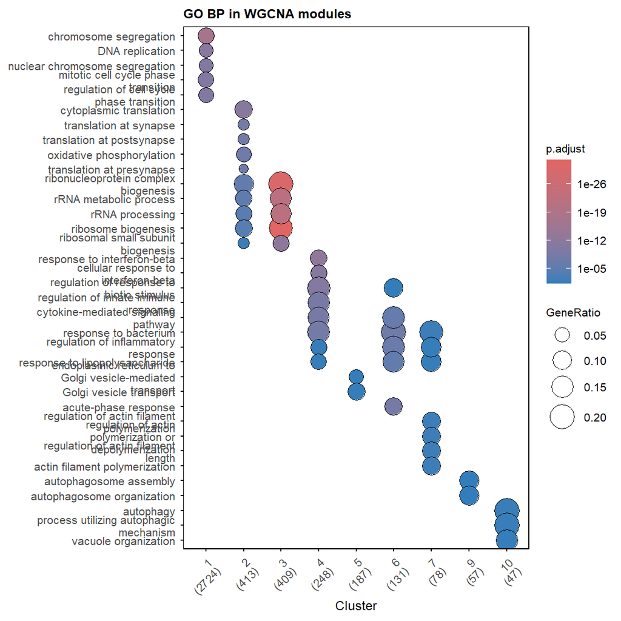

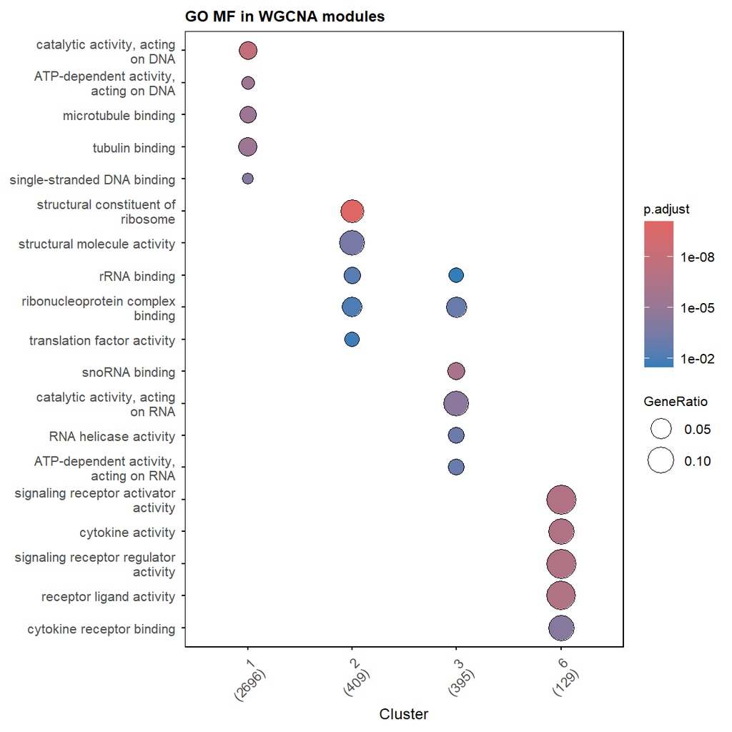

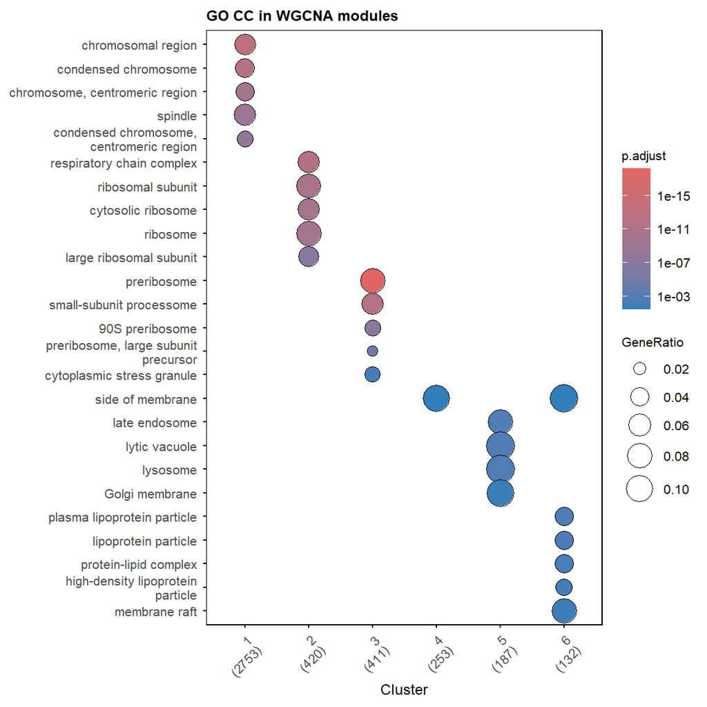

```r
plot_GO(go_list_wgcna_merged_no0$all,
    plot_dotplot = TRUE,
    showCategory_dotplot = 5,
    label = "WGCNA modules"
)
```